# birddatacleaning

Tom Levy

4/12/2022

## Initial EBird Library + Tests of Commnds

```r
library(rebird)
EBIRD_KEY <- "q3delvootbg0"
nearestobs(species_code('branta canadensis'), locname = "US-NJ", obsDt = '2022-02-28 0:00', back = 30, key = EBIRD_KEY)
```

```
## Canada Goose (Branta canadensis): cangoo
```

```
## # A tibble: 208 × 13
##    speciesCode comName  sciName locId locName obsDt howMany   lat   lng obsValid
##    <chr>       <chr>    <chr>   <chr> <chr>   <chr>   <int> <dbl> <dbl> <lgl>
##  1 cangoo      Canada … Branta… L133… Patter… 2022…       3  40.2 -74.9 TRUE
##  2 cangoo      Canada … Branta… L211… Church… 2022…       6  40.2 -75.0 TRUE
##  3 cangoo      Canada … Branta… L188… Hamilt… 2022…       2  40.3 -74.7 TRUE
##  4 cangoo      Canada … Branta… L150… Silver… 2022…       4  40.1 -74.9 TRUE
##  5 cangoo      Canada … Branta… L188… Church… 2022…       1  40.2 -75.0 TRUE
##  6 cangoo      Canada … Branta… L987… Miry R… 2022…       2  40.2 -74.7 TRUE
##  7 cangoo      Canada … Branta… L188… 2192–2… 2022…       9  40.2 -74.9 TRUE
##  8 cangoo      Canada … Branta… L165… Plains… 2022…       3  40.4 -74.6 TRUE
##  9 cangoo      Canada … Branta… L587… Villag… 2022…       9  40.2 -75.0 TRUE
## 10 cangoo      Canada … Branta… L178… Lake C… 2022…       2  40.3 -74.6 TRUE
## # … with 198 more rows, and 3 more variables: obsReviewed <lgl>,
## #   locationPrivate <lgl>, subId <chr>
```

```r
ebirdhistorical(loc = 'US-NJ', date = '2019-02-28', key = EBIRD_KEY)
```

```
## # A tibble: 141 × 13
##    speciesCode comName  sciName locId locName obsDt howMany   lat   lng obsValid
##    <chr>       <chr>    <chr>   <chr> <chr>   <chr>   <int> <dbl> <dbl> <lgl>
##  1 grhowl      Great H… Bubo v… L166… Jamesb… 2019…       1  40.4 -74.4 TRUE
##  2 cangoo      Canada … Branta… L302… Great … 2019…       2  40.7 -74.5 TRUE
##  3 brdowl      Barred … Strix … L302… Great … 2019…       2  40.7 -74.5 TRUE
##  4 buffle      Buffleh… Buceph… L871… Ramapo… 2019…       1  41.0 -74.3 TRUE
##  5 blujay      Blue Jay Cyanoc… L196… Wayne   2019…      NA  40.9 -74.3 TRUE
##  6 whbnut      White-b… Sitta … L196… Wayne   2019…       1  40.9 -74.3 TRUE
##  7 eursta      Europea… Sturnu… L196… Wayne   2019…       1  40.9 -74.3 TRUE
##  8 houspa      House S… Passer… L196… Wayne   2019…      NA  40.9 -74.3 TRUE
##  9 daejun      Dark-ey… Junco … L196… Wayne   2019…       2  40.9 -74.3 TRUE
## 10 sonspa      Song Sp… Melosp… L196… Wayne   2019…       2  40.9 -74.3 TRUE
## # … with 131 more rows, and 3 more variables: obsReviewed <lgl>,
## #   locationPrivate <lgl>, subId <chr>
```

## Data Collection

NOTE: I have commented out the initial data collection chunks since R Markdown will not let it knit efficiently.

```r
library(tidyverse)
library(stringr)
library(broom)
```

```r
#dates <- seq(as.Date("2017-4-1"), as.Date("2022-4-1"), "days")
#date_index <- 1:length(dates)
#goose_tibble <- tibble()

#for (i in date_index) {
#  print(i)
#  goose_tibble <- goose_tibble %>% bind_rows(ebirdhistorical(loc = 'US-NJ', date = dates[i], key = EBIRD_KEY))
#}

#goose_tibble
```

```r
#goose_filtered_tibble <- goose_tibble %>% filter(comName == 'Red-winged Blackbird')
#goose_filtered_tibble
```

```r
#goose_filtered_tibble$idu <- row.names(goose_filtered_tibble)
#goose_filtered_tibble$idu <- as.numeric(row.names(goose_filtered_tibble))

#goose_filtered_tibble[is.na(goose_filtered_tibble)] <- 0

#goose_filtered_tibble %>% ggplot(aes(y = howMany,x = idu)) +
#  geom_line() +  ggtitle("New Jersey Red-Winged Blackbird Index Plot") + theme(plot.title = element_text(size = 10)) + #theme(plot.title = element_text(hjust = 0.5)) + xlab("Index") + ylab("# of Red-Winged Blackbirds")
```

##File Write + Re-load

```r
#library(glue)
#write.table(goose_filtered_tibble, file = "US_NJ_RedWinged_Blackbird.csv", sep=",", row.names=FALSE)
```

Data imported from working directory pane.

## Group by Month + Fourth-Root Transform

We chose to group by month to account for sampling inconsistencies and the below plot still had clear outliers, so we took fourth roots.

```r
us_nj <- read_csv("US_NJ_RedWinged_Blackbird.csv")
```

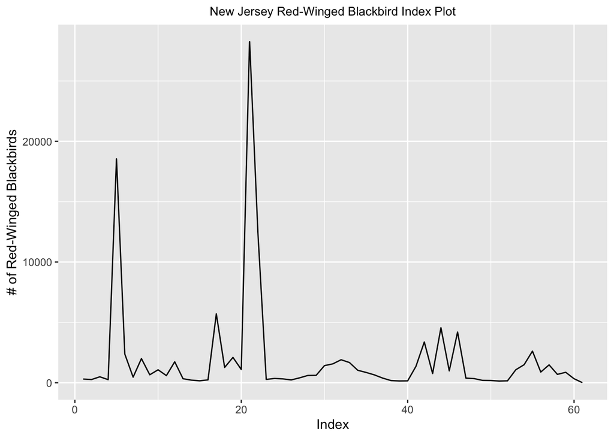

```r
us_nj_fixed <- us_nj %>% mutate(., fixed_date = substring(as.character(obsDt), 1, 7)) %>% group_by(fixed_date) %>% summarize(monthly_birds = sum(howMany))

us_nj_fixed$idu <- row.names(us_nj_fixed)
us_nj_fixed$idu <- as.numeric(row.names(us_nj_fixed))

us_nj_fixed[is.na(us_nj_fixed)] <- 0

us_nj_fixed %>% ggplot(aes(y = monthly_birds,x = idu)) +
  geom_line() +  ggtitle("New Jersey Red-Winged Blackbird Index Plot") + theme(plot.title = element_text(size = 10)) + theme(plot.title = element_text(hjust = 0.5)) + xlab("Index") + ylab("# of Red-Winged Blackbirds")
```

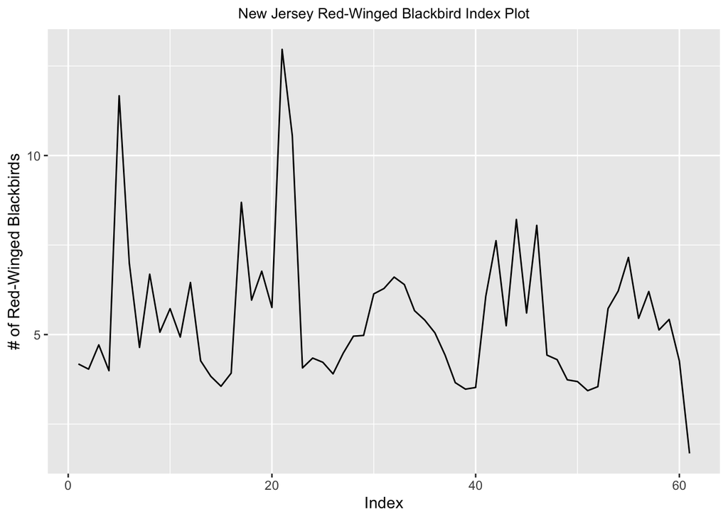

```r
us_nj_fixed %>% ggplot(aes(y = monthly_birds^0.25,x = idu)) +
  geom_line() +  ggtitle("New Jersey Red-Winged Blackbird Index Plot") + theme(plot.title = element_text(size = 10)) + theme(plot.title = element_text(hjust = 0.5)) + xlab("Index") + ylab("# of Red-Winged Blackbirds")
```

## ARIMA/SARIMA

We did a seasonal-transform of the data after fourth-rooting it and found our ARIMA + SARIMA models from there.

```r
library(forecast)
nj_blackbirds <- us_nj_fixed %>% select(monthly_birds) %>% .^0.25
nj_ts <- ts(nj_blackbirds, frequency=3)
auto.arima(nj_ts, D=1)
```

```
## Series: nj_ts
## ARIMA(0,0,1)(2,1,1)[3]
##
## Coefficients:
##          ma1     sar1     sar2     sma1
##       0.2560  -0.1667  -0.4614  -0.7772
## s.e.  0.1323   0.1987   0.1576   0.2773
##
## sigma^2 = 3.495:  log likelihood = -119.69
## AIC=249.37   AICc=250.53   BIC=259.68
```

```r
auto.arima(nj_ts)
```

```
## Series: nj_ts
## ARIMA(1,0,0) with non-zero mean
##
## Coefficients:
##          ar1    mean
##       0.3321  5.4368
## s.e.  0.1241  0.3539
##
## sigma^2 = 3.567:  log likelihood = -124.39
## AIC=254.77   AICc=255.19   BIC=261.1
```

## ADF Test + 12-Step Ahead Forecast

Below, we plotted our 12-Step ahead forecast to predict what another season would look like for the Red-Winged Blackbird population.

```r
library(tseries)
dickey_tibble <- tibble()

for (i in 1:20) {
  dickey_tibble <- dickey_tibble %>% bind_rows(adf.test(nj_ts, alternative = "stationary", k = i) %>% tidy())
}
dickey_tibble %>% filter(p.value == min(p.value))
```

```
## # A tibble: 8 × 5
##   statistic p.value parameter method                       alternative
##       <dbl>   <dbl>     <dbl> <chr>                        <chr>
## 1     -4.44    0.01         1 Augmented Dickey-Fuller Test stationary
## 2     -4.22    0.01         2 Augmented Dickey-Fuller Test stationary
## 3     -4.14    0.01         3 Augmented Dickey-Fuller Test stationary
## 4     -5.13    0.01         5 Augmented Dickey-Fuller Test stationary
## 5     -4.74    0.01         6 Augmented Dickey-Fuller Test stationary
## 6     -4.90    0.01         7 Augmented Dickey-Fuller Test stationary
## 7     -4.75    0.01        19 Augmented Dickey-Fuller Test stationary
## 8     -4.26    0.01        20 Augmented Dickey-Fuller Test stationary
```

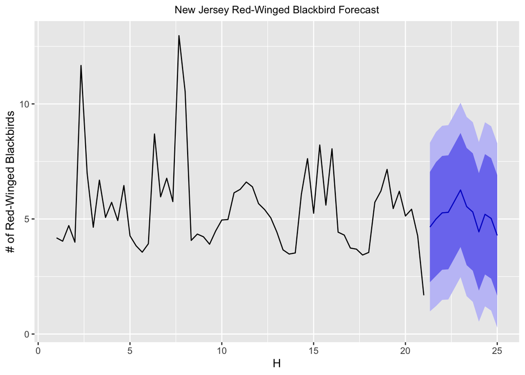

```r
library(forecast)
sarima_model = auto.arima(nj_ts, D=1)
autoplot(forecast::forecast(sarima_model, h=12), level = c(90)) + ggtitle("New Jersey Red-Winged Blackbird Forecast") + theme(plot.title = element_text(size = 10)) + theme(plot.title = element_text(hjust = 0.5)) + xlab("H") + ylab("# of Red-Winged Blackbirds")
```

## ACF/PACF Plots

We got the autocorrelations + partial autocorrelations and made a dataframe including the lag. Since SARIMA was a better fit for our data from the previous results, we built a confidence interval using ggfortify with the type being for a SARIMA model. We added dashed lines corresponding to our CIs as well as the corresponding vertical line segments corresponding to each ACF/PACF respectively.

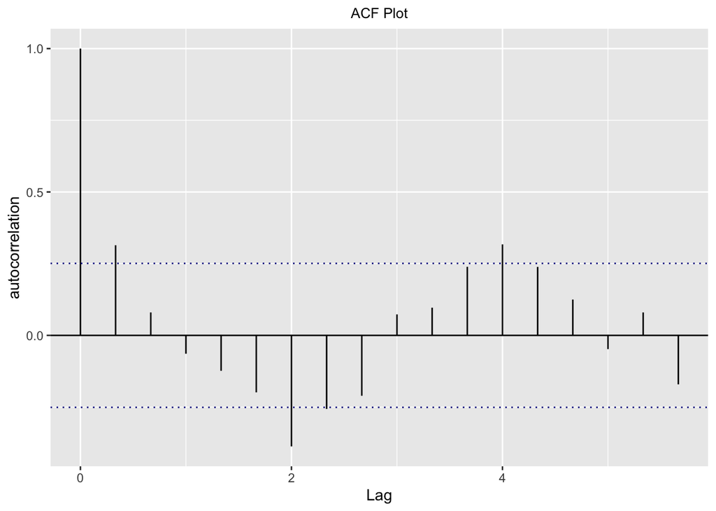

```r
#x <- auto.arima(nj_ts, D=1)

bacf <- acf(nj_ts, plot = FALSE)
bacfdf <- with(bacf, data.frame(lag, acf))
cil <- ggfortify:::confint.acf(acf(nj_ts, plot = FALSE), ci.type = 'sarima')
q <- ggplot(data = bacfdf, mapping = aes(x = lag, y = acf)) +
       geom_hline(aes(yintercept = 0)) +
       geom_segment(mapping = aes(xend = lag, yend = 0)) + geom_hline(aes(yintercept = cil), linetype = 3, color = 'darkblue') + geom_hline(aes(yintercept = -cil), linetype = 3, color = 'darkblue') + ggtitle("ACF Plot") + theme(plot.title = element_text(size = 10)) + theme(plot.title = element_text(hjust = 0.5)) + xlab("Lag") + ylab("autocorrelation")
q
```

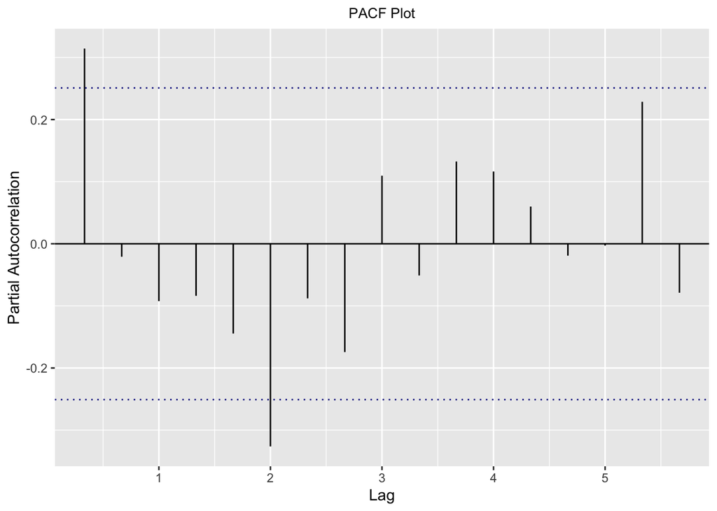

```r
bpacf <- pacf(nj_ts, plot = FALSE)
bpacfdf <- with(bpacf, data.frame(lag, acf))
cill <- ggfortify:::confint.acf(pacf(nj_ts, plot = FALSE), ci.type = 'sarima')

q <- ggplot(data = bpacfdf, mapping = aes(x = lag, y = acf)) +
       geom_hline(aes(yintercept = 0)) +
       geom_segment(mapping = aes(xend = lag, yend = 0)) + geom_hline(aes(yintercept = cill), linetype = 3, color = 'darkblue') + geom_hline(aes(yintercept = -cill), linetype = 3, color = 'darkblue') + ggtitle("PACF Plot") + theme(plot.title = element_text(size = 10)) + theme(plot.title = element_text(hjust = 0.5)) + xlab("Lag") + ylab("Partial Autocorrelation")
q
```

# Box-Ljung Test

For the Box-Ljung Test, we did a similar procedure that we did for the ADF test insofar as storing our results. With each successive lag, its performance got worse, so we did not perform any differencing at this point.

```r
box_tibble <- tibble()

for (i in 1:20) {
box_tibble <- box_tibble %>% bind_rows(Box.test(nj_ts, lag = i, type = "Ljung") %>% tidy())
}

box_tibble
```

```
## # A tibble: 20 × 4
##    statistic     p.value parameter method
##        <dbl>       <dbl>     <dbl> <chr>
##  1      6.33 0.0119              1 Box-Ljung test
##  2      6.74 0.0343              2 Box-Ljung test
##  3      7.02 0.0714              3 Box-Ljung test
##  4      8.05 0.0899              4 Box-Ljung test
##  5     10.8  0.0564              5 Box-Ljung test
##  6     21.2  0.00167             6 Box-Ljung test
##  7     25.9  0.000521            7 Box-Ljung test
##  8     29.1  0.000301            8 Box-Ljung test
##  9     29.5  0.000528            9 Box-Ljung test
## 10     30.2  0.000786           10 Box-Ljung test
## 11     34.6  0.000286           11 Box-Ljung test
## 12     42.5  0.0000273          12 Box-Ljung test
## 13     47.1  0.00000937         13 Box-Ljung test
## 14     48.4  0.0000115          14 Box-Ljung test
## 15     48.5  0.0000208          15 Box-Ljung test
## 16     49.1  0.0000319          16 Box-Ljung test
## 17     51.6  0.0000234          17 Box-Ljung test
## 18     61.2  0.00000133         18 Box-Ljung test
## 19     68.2  0.000000183        19 Box-Ljung test
## 20     69.2  0.000000242        20 Box-Ljung test
```

## Exponential Smoothing

We sought to try exponential smoothing as a means to account for the seasonality in our data. We imported smooth and greybox to smooth our time series + fit it to an exponential smoothing function respectively. Regardless of our alpha value, the exponential smoothing technique did not properly account for the seasonality in our data.

We tried to do an 80-20 train-test split to get an idea of what alpha we should use in our exponential smoothing function. 0.99 ended up being the alpha value that returned the lowest RMSE.

```r
library(smooth)
library(greybox)
es(nj_ts, h=12, holdout=TRUE, silent=FALSE)
```

```
## Forming the pool of models based on... ANN, ANA, AAN, Estimation progress:    100%... Done!
```

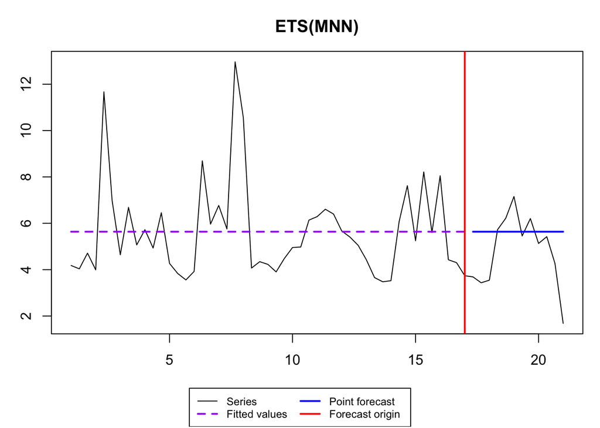

```
## Time elapsed: 0.55 seconds
## Model estimated: ETS(MNN)
## Persistence vector g:
## alpha
##     0
## Initial values were optimised.
##
## Loss function type: likelihood; Loss function value: 104.3708
## Error standard deviation: 0.3688
## Sample size: 49
## Number of estimated parameters: 2
## Number of provided parameters: 1
## Number of degrees of freedom: 47
## Information criteria:
##      AIC     AICc      BIC     BICc
## 212.7416 213.0024 216.5252 217.0328
##
## Forecast errors:
## MPE: -34.9%; sCE: -172.5%; Asymmetry: -58.9%; MAPE: 41.8%
## MASE: 0.791; sMAE: 22.5%; sMSE: 8.9%; rMAE: 0.833; rRMSE: 0.917
```

```r
library(fpp2)
```

[figure not shown]

```r
autoplot(ses(nj_ts, alpha=0.99, h=12)) + ggtitle("500-Step Ahead Exponential Smoothing Forecast") + theme(plot.title = element_text(size = 10)) + theme(plot.title = element_text(hjust = 0.5)) + xlab("H") + ylab("Value")
```

[figure not shown]

```r
autoplot(ses(nj_ts), alpha=0.2, h=12) + ggtitle("500-Step Ahead Differenced Exponential Smoothing Forecast") + theme(plot.title = element_text(size = 10)) + theme(plot.title = element_text(hjust = 0.5)) + xlab("H") + ylab("Differenced Value")
```

```r
nj_ts_train <- nj_ts[1:48]
nj_ts_test <- nj_ts[49:60]

nj_ts_ses <- ses(nj_ts_train,
                    alpha = .2,
                    h = 12)

accuracy(nj_ts_ses, nj_ts_test)
```

```
##                       ME     RMSE      MAE        MPE     MAPE      MASE
## Training set  0.02764954 2.159826 1.572965  -9.509534 27.53604 0.9673505
## Test set     -0.59897990 1.330096 1.084590 -18.734395 26.03179 0.6670069
##                   ACF1
## Training set 0.2126878
## Test set            NA
```

```r
alpha <- seq(.01, .99, by = .01)
RMSE <- NA
for(i in seq_along(alpha)) {
  fit <- ses(nj_ts_train, alpha = alpha[i],
             h = 12)
  RMSE[i] <- accuracy(fit,
                      diff(nj_ts_test))[2,2]
}

alpha.fit <- data_frame(alpha, RMSE)
```

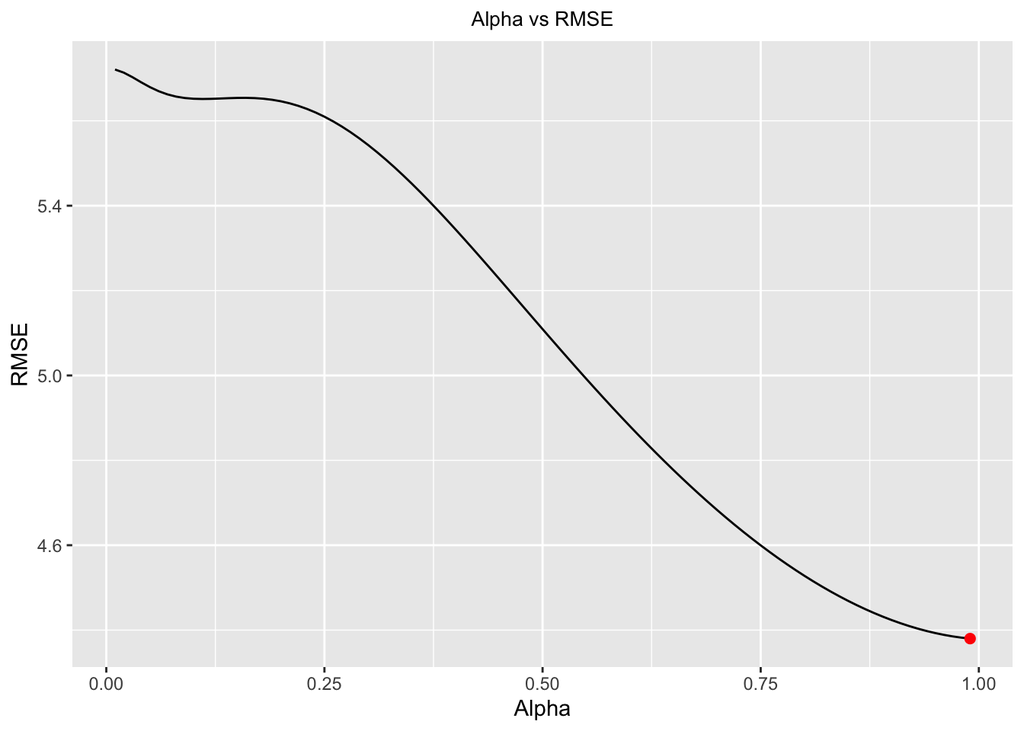

```r
alpha.min <- filter(alpha.fit,
                    RMSE == min(RMSE))

ggplot(alpha.fit, aes(alpha, RMSE)) +
  geom_line() +
  geom_point(data = alpha.min,
             aes(alpha, RMSE),
             size = 2, color = "red") + ggtitle("Alpha vs RMSE") + theme(plot.title = element_text(size = 10)) + theme(plot.title = element_text(hjust = 0.5)) + xlab("Alpha") + ylab("RMSE")
```

```
## Forming the pool of models based on... ANN, ANA, AAN, Estimation progress:    100%... Done!
```

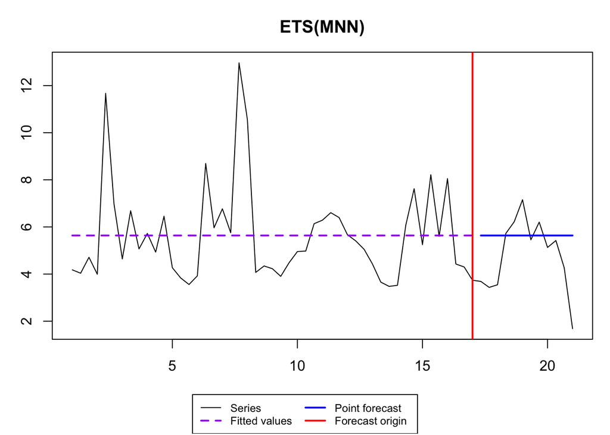

```
## Time elapsed: 0.38 seconds
## Model estimated: ETS(MNN)
## Persistence vector g:
## alpha
##     0
## Initial values were optimised.
##
## Loss function type: likelihood; Loss function value: 104.3708
## Error standard deviation: 0.3688
## Sample size: 49
## Number of estimated parameters: 2
## Number of provided parameters: 1
## Number of degrees of freedom: 47
## Information criteria:
##      AIC     AICc      BIC     BICc
## 212.7416 213.0024 216.5252 217.0328
##
## Forecast errors:
## MPE: -34.9%; sCE: -172.5%; Asymmetry: -58.9%; MAPE: 41.8%
## MASE: 0.791; sMAE: 22.5%; sMSE: 8.9%; rMAE: 0.833; rRMSE: 0.917
```

```r
es(nj_ts, h=12, holdout=TRUE, silent=FALSE, plot=FALSE)
```

```r
print(alpha.min)
```

```
## # A tibble: 1 × 2
##   alpha  RMSE
##   <dbl> <dbl>
## 1  0.99  4.38
```

## Conclusions

While exponential smoothing yielded the lower AIC values, it did not take into account the seasonality of the data in its forecasting (just a near-straight horizontal line), which makes it a worse fit to predict future Red-winged blackbird migration trends. The seasonal ARIMA model of (0,0,1)(2,1,1)[3] is our best fit.